# GHFC Co-op Reopening Checkin Desk Analysis

Josh Hadro

2021-02-01

# Last January Weekend report

Here are the recorded numbers for the last few days:

Checkins Friday: `36`  
Checkins Saturday: `68`  
Checkins Sunday:`95`

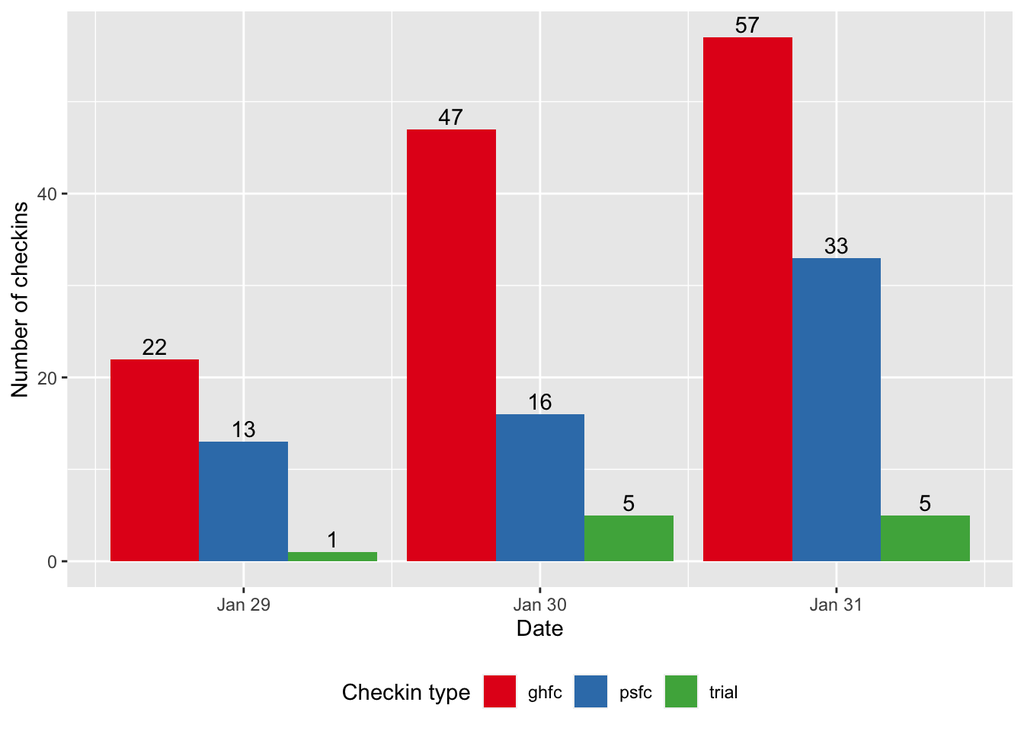

### Biggest shopping days

Sunday, January 31 was the Co-ops largest recorded day in terms of checkins; as Amanda LP put it, “mostly because of snowstorm as well as PSFC being closed.”

The other top 10 days are show below.

Interestingly, four of the top 10 checkin days have been in the last few weeks.

| Date | Total Checkins | Day of the week | Note |
| --- | --- | --- | --- |
| 2021-01-31 | 95 | Sunday | Sunday before major snowstorm |
| 2020-09-13 | 77 | Sunday | Sunday after Labor Day |
| 2020-11-22 | 75 | Sunday | Sunday before Thanksgiving |
| 2020-11-15 | 74 | Sunday | NA |
| 2020-10-25 | 72 | Sunday | NA |
| 2020-06-14 | 71 | Sunday | NA |
| 2021-01-17 | 71 | Sunday | NA |
| 2020-11-01 | 70 | Sunday | NA |
| 2021-01-24 | 70 | Sunday | NA |
| 2021-01-09 | 69 | Saturday | NA |

# Recurring report

In June 2020 the Co-op reinstated its check-in procedure. As part of the IT group’s work to revise the check-in application, we’re able to capture a lot more usable data for analysis of who is coming into the store and when.

A server restart issue caused a logging error from June 26 - July 1, which is apparent in the figures below where there is missing data.

(See the previous report [(“GHFC Co-op Checkin Desk Analysis”)](https://hadro.github.io/ghfc/ghfc_psfc_report) for a view into the data we were able analyze from mid-March 2019 through mid-March 2020, when the previous iteration of the check-in desk was in operation.)

N.B.: this data reflects only what was captured – put another way, if people did not check in at the check-in desk or mis-entered their data, then those statistics would not, by definition, be captured here. That said, I have no reason to believe the figures here are under-representative in any significant way. Moreover, the improved UX of the new checkin desk makes it easy to check in, and I’m confident in the few days of data we have.

## Shoppers per day

The following figure shows the number of shoppers per day starting June 05. Each dot represents the total number of check-ins on a single day.

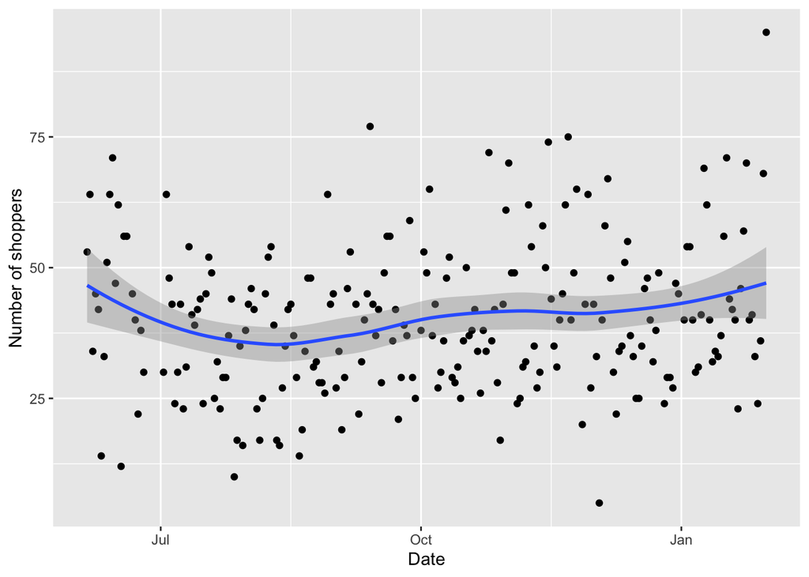

### Shoppers per week, by type

Meanwhile, the revised check-in system allows for more granular faceting. For example, we now capture more specifically what type of visitor each check-in is associated with.

There are four possible values:

- GHFC (Greene Hill Food Co-op member)
- PSFC (Park Slope Food Co-op member)
- Trial member
- Visitor

### Proportions of shopper types

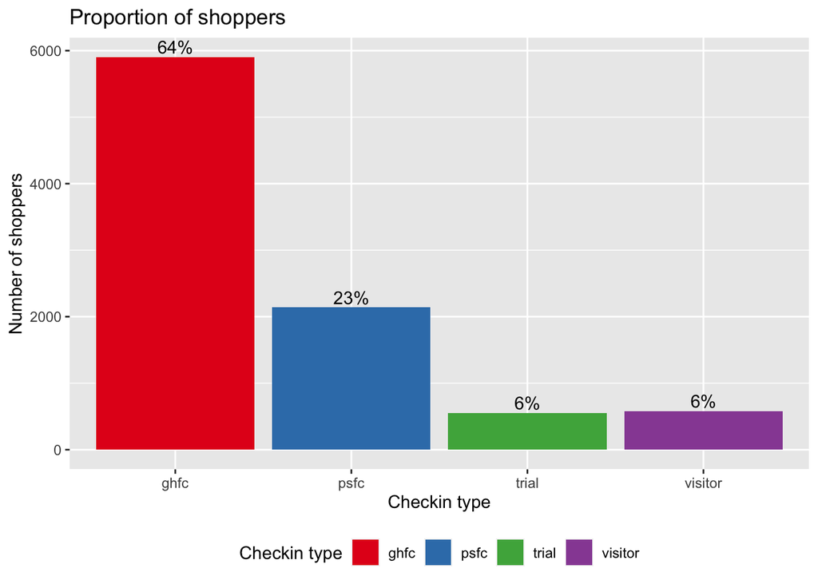

#### GHFC shoppers per day, by checkin type

To give you a sense of relative daily numbers, the figure below shows the total shoppers per day broken out by each of these four check-in types.

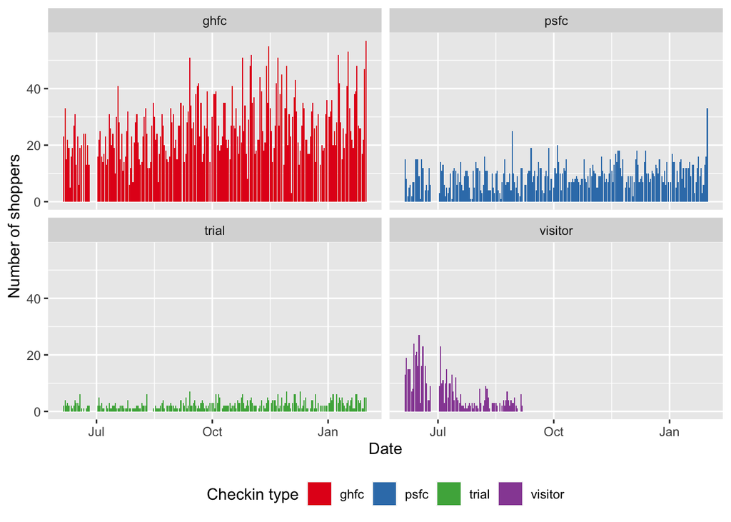

#### GHFC shoppers per day, by membership plan

Likewise, now with the new check-in desk we can also look at how the various membership plans within the GHFC check-in type are represented over the same period. In particular, how many folks are taking advantage of the Summer Special Zucchini Plan.

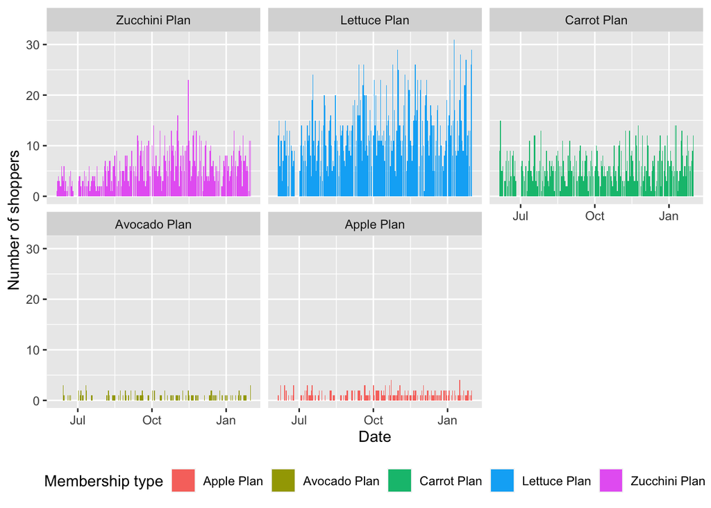

### Average shoppers by day of the week and hour of the day

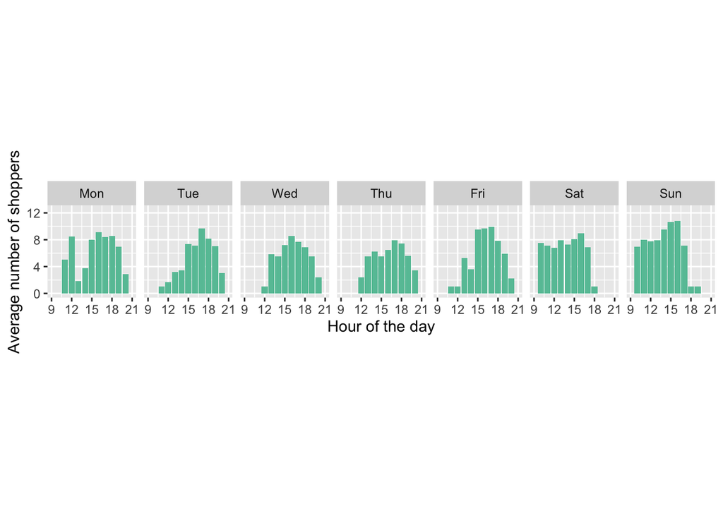

Or we can look at the same data by day and time, an also add in checkin type:

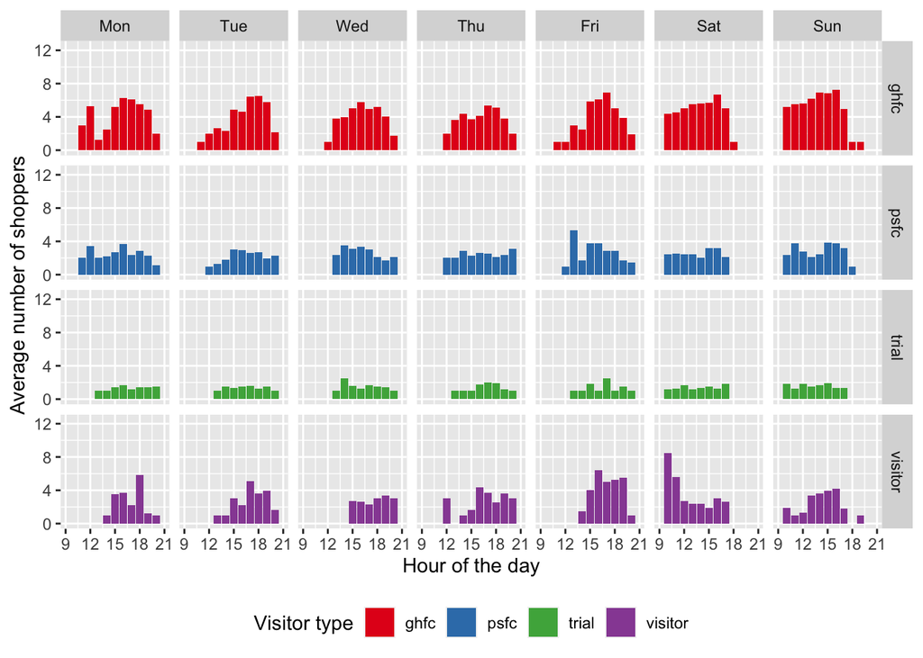

That’s it for now – but as always, please let me know if there’s a question you’d like to investigate based on this data or any other data, and I’ll be happy to take a look.